# index

## Tutorial: Explaining the Data Science Pipeline

### Introduction

*Goal:* By the end of this tutorial, you would have obtained insight on how the datascience pipeline works, and you will be able to utilize this to perform proper data science on any data.

### About the dataset

The data set I've chosen for this tutorial is a covid-19 dataset from the Covid Tracking Project.

- Learn more about the Covid Tracking Project [here]
- Download and learn more about the dataset [here](https://docs.microsoft.com/en-us/azure/open-datasets/dataset-covid-tracking?tabs=azure-storage)
- [covid_trackin.csv](https://docs.microsoft.com/en-us/azure/open-datasets/dataset-covid-tracking?tabs=azure-storage)

First we'll import a few packages that we'll need for this tutorial.

```python
import pandas as pd
import numpy as np
import missingno as msno
import requests as req
import matplotlib.pyplot as plt
import seaborn as sbrn
from sklearn import linear_model
from sklearn.model_selection import train_test_split
from sklearn.tree import DecisionTreeClassifier
```

### Loading our data

Now that we have all the necessary packages to manupulate our data, it's time to load our data into python. In our case, we've already downloaded our data unto local our machine (in the same directory as this notebook) in the form of CSV(comma-separated values) files. We'll use pandas to read these csv files into memory and turn them into tables that we can manipulate.

```python
data = pd.read_csv('covid_tracking.csv')
print("Shape:", data.shape)
data.head()
```

```
Shape: (22261, 31)
```

|  | date | state | positive | negative | pending | hospitalized_currently | hospitalized_cumulative | in_icu_currently | in_icu_cumulative | on_ventilator_currently | ... | fips | death_increase | hospitalized_increase | negative_increase | positive_increase | total_test_results_increase | fips_code | iso_subdivision | load_time | iso_country |
| --- | --- | --- | --- | --- | --- | --- | --- | --- | --- | --- | --- | --- | --- | --- | --- | --- | --- | --- | --- | --- | --- |
| 0 | 2021-03-07 | AK | 56886.0 | NaN | NaN | 33.0 | 1293.0 | NaN | NaN | 2.0 | ... | 2 | 0 | 0 | 0 | 0.0 | 0 | 2 | US-AK | 2021-07-20 00:05:40 | US |
| 1 | 2021-03-07 | AL | 499819.0 | 1931711.0 | NaN | 494.0 | 45976.0 | NaN | 2676.0 | NaN | ... | 1 | -1 | 0 | 2087 | 408.0 | 2347 | 1 | US-AL | 2021-07-20 00:05:40 | US |
| 2 | 2021-03-07 | AR | 324818.0 | 2480716.0 | NaN | 335.0 | 14926.0 | 141.0 | NaN | 65.0 | ... | 5 | 22 | 11 | 3267 | 165.0 | 3380 | 5 | US-AR | 2021-07-20 00:05:40 | US |
| 3 | 2021-03-07 | AS | 0.0 | 2140.0 | NaN | NaN | NaN | NaN | NaN | NaN | ... | 60 | 0 | 0 | 0 | 0.0 | 0 | 60 | US-AS | 2021-07-20 00:05:40 | US |
| 4 | 2021-03-07 | AZ | 826454.0 | 3073010.0 | NaN | 963.0 | 57907.0 | 273.0 | NaN | 143.0 | ... | 4 | 5 | 44 | 13678 | 1335.0 | 45110 | 4 | US-AZ | 2021-07-20 00:05:40 | US |

5 rows × 31 columns

### Data representation:

- *date-* Date for which the daily totals were collected
- *positive-* Total number of people who have tested positive for COVID-19 so far
- *negative-* Total number of people who have negative positive for COVID-19 so far
- *hospitalized_currently-* Number of people in hospital for COVID-19 on this day
- *hospitalized_cumulative-* tal number of people who have gone to the hospital for COVID-19 so far, including those who have since recovered or died.
- *in_icu_currently-* Total number of people in the ICU for COVID-19 on this day
- *in_icu_cumulative-* Total number of people who have gone to the ICU for COVID-19 so far, including those who have since recovered or died
- *recovered-* Total number of people who have recovered from COVID-19 so far.
- *death-* Total number of people who have died as a result of COVID-19 so far.

### Tidying the data

- For this tutorial, we're only Maryland, we'll only collect data (relevant columns) for MD. We'll also sort this in ascending order of date. This might be useful later during analysis

```python
print(list(data.columns))
```

```
['date', 'state', 'positive', 'negative', 'pending', 'hospitalized_currently', 'hospitalized_cumulative', 'in_icu_currently', 'in_icu_cumulative', 'on_ventilator_currently', 'on_ventilator_cumulative', 'recovered', 'data_quality_grade', 'last_update_et', 'hash', 'date_checked', 'death', 'hospitalize…
```

```python
# columns to keep
cols = ['date', 'state', 'positive', 'negative', 'hospitalized_currently', 'hospitalized_cumulative', 'in_icu_currently', 'in_icu_cumulative', 'recovered', 'death', 'hospitalized']
data = data.loc[data['state'] == 'MD'][cols].sort_values(by='date')
print(data.shape)
data.head()
```

```
(368, 11)
```

|  | date | state | positive | negative | hospitalized_currently | hospitalized_cumulative | in_icu_currently | in_icu_cumulative | recovered | death | hospitalized |
| --- | --- | --- | --- | --- | --- | --- | --- | --- | --- | --- | --- |
| 21971 | 2020-03-05 | MD | 0.0 | 17.0 | NaN | NaN | NaN | NaN | NaN | NaN | NaN |
| 21933 | 2020-03-06 | MD | 3.0 | 26.0 | NaN | NaN | NaN | NaN | NaN | NaN | NaN |
| 21881 | 2020-03-07 | MD | 3.0 | 41.0 | NaN | NaN | NaN | NaN | NaN | NaN | NaN |
| 21826 | 2020-03-08 | MD | 3.0 | 52.0 | NaN | NaN | NaN | NaN | NaN | NaN | NaN |
| 21771 | 2020-03-09 | MD | 5.0 | 73.0 | NaN | NaN | NaN | NaN | NaN | NaN | NaN |

```python
mounths = data.date.str[0:7].unique()
```

### Dealing with missing data

That looks better, but it looks like we have a lot of missing data. Missing data in our table could lead to complications when performing row operations and could possibly yield wrong results if not handled properly. So it is important to check for missing data and deal with it prior to performing analysis.

- I'll use the *missingno library* to visualize missing data. Then, based on that, I'll determine how to deal with the missing data.

### Vizualization of missing data

*missingno* provides a good library for vizualising null/missing data.

1. First I'll display the Nullity matrix below.

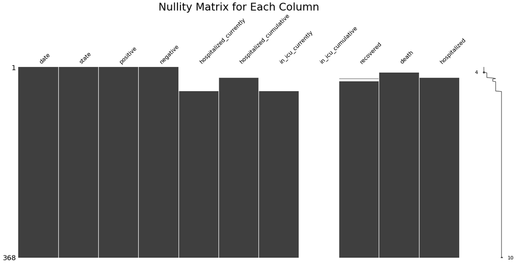

```python
diagram = msno.matrix(data)
diagram.set_title("Nullity Matrix for Each Column", fontsize=30)
```

The empty/white spaces on the matrix indicate areas of missing data.

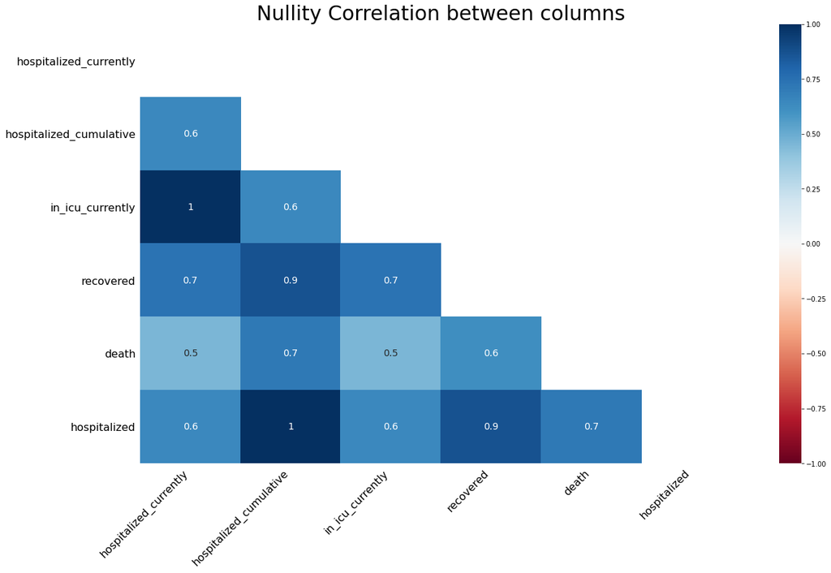

```python
# drop the 2 columns
data = data.drop(['in_icu_cumulative'], axis=1)

# display correlation matrix
diagram = msno.heatmap(data)
diagram.set_title('Nullity Correlation between columns', fontsize=30)
```

Values closer to one represent columns with a strong correlation.  
example: the columns of *recovered* and *hospitalized* are closely correlated. The correlations might be worth looking at when analyzing the data.  
Now let's count the number of missing values, this will help us determine how to impute the data.

```python
count_missing_df = pd.DataFrame(data.isna().sum(), columns=[f"#missing"])
count_missing_df[(count_missing_df.T != 0).any()]
count_missing_df['missing_%'] = round(count_missing_df['#missing']*100/data.shape[0],2)
count_missing_df
```

|  | #missing | missing_% |
| --- | --- | --- |
| date | 0 | 0.00 |
| state | 0 | 0.00 |
| positive | 0 | 0.00 |
| negative | 0 | 0.00 |
| hospitalized_currently | 47 | 12.77 |
| hospitalized_cumulative | 21 | 5.71 |
| in_icu_currently | 47 | 12.77 |
| recovered | 27 | 7.34 |
| death | 11 | 2.99 |
| hospitalized | 21 | 5.71 |

### Imputation

This is where we replace missing data to avoid problems with future calculations. We'll could use mean use mean imputation: replacing each missing data with the mean of its column. Below is the code for that

```python
# data['hospitalized_currently'].fillna((data['hospitalized_currently'].mean()), inplace=True)
# data['in_icu_currently'].fillna((data['in_icu_currently'].mean()), inplace=True)
# data['recovered'].fillna((data['recovered'].mean()), inplace=True)
# data['hospitalized'].fillna((data['hospitalized'].mean()), inplace=True)
# data['death'].fillna((data['death'].mean()), inplace=True)
# data['hospitalized_cumulative'].fillna((data['hospitalized_cumulative'].mean()), inplace=True)
# data.isnull().values.any()
```

However, I've decided to only analyse rows where 'death' column is not not. In this case, we'll loose 3% of the data, which is acceptable. Below I'll collect the rows we need.

```python
data = data.loc[data.death.notna()]
data
```

|  | date | state | positive | negative | hospitalized_currently | hospitalized_cumulative | in_icu_currently | recovered | death | hospitalized |
| --- | --- | --- | --- | --- | --- | --- | --- | --- | --- | --- |
| 21383 | 2020-03-16 | MD | 37.0 | 94.0 | NaN | NaN | NaN | NaN | 2.0 | NaN |
| 21323 | 2020-03-17 | MD | 57.0 | 94.0 | NaN | NaN | NaN | NaN | 2.0 | NaN |
| 21263 | 2020-03-18 | MD | 85.0 | 94.0 | NaN | NaN | NaN | NaN | 2.0 | NaN |
| 21203 | 2020-03-19 | MD | 107.0 | 94.0 | NaN | NaN | NaN | NaN | 2.0 | NaN |
| 21143 | 2020-03-20 | MD | 149.0 | 94.0 | NaN | NaN | NaN | NaN | 3.0 | NaN |
| ... | ... | ... | ... | ... | ... | ... | ... | ... | ... | ... |
| 263 | 2021-03-03 | MD | 383956.0 | 3012179.0 | 863.0 | 35223.0 | 228.0 | 9685.0 | 7919.0 | 35223.0 |
| 203 | 2021-03-04 | MD | 384765.0 | 3018120.0 | 856.0 | 35304.0 | 216.0 | 9691.0 | 7922.0 | 35304.0 |
| 143 | 2021-03-05 | MD | 385678.0 | 3024949.0 | 849.0 | 35378.0 | 229.0 | 9701.0 | 7930.0 | 35378.0 |
| 83 | 2021-03-06 | MD | 386610.0 | 3032496.0 | 830.0 | 35572.0 | 230.0 | 9703.0 | 7941.0 | 35572.0 |
| 23 | 2021-03-07 | MD | 387319.0 | 3034546.0 | 818.0 | 35651.0 | 215.0 | 9703.0 | 7955.0 | 35651.0 |

357 rows × 10 columns

### EDA: Exploratory Data Analysis

In this phase of the data pipeline, this is where we make visual representations of our data and try to find patterns. In this phase we may try to view the data from multiple angles to see if we can come up with hypotheses. This is important because without a hypothesis, we might not know what to expect from the data. Our hypotheses might not always be true, but it most cases, they help to uncover more information about the data. This is where some visualizations of our data come in handy

Remember, our aim is to find out if there is a relation between covid cases, deaths, hospitalization, and what that relationship is? Perhpars there's a trend that varies with time?.

At this point, it'll be great to have vizualize the data to see what's going on.

```python
data.corr()
```

|  | positive | negative | hospitalized_currently | hospitalized_cumulative | in_icu_currently | recovered | death | hospitalized |
| --- | --- | --- | --- | --- | --- | --- | --- | --- |
| positive | 1.000000 | 0.965278 | 0.428098 | 0.990261 | 0.100531 | 0.861617 | 0.961566 | 0.990261 |
| negative | 0.965278 | 1.000000 | 0.334271 | 0.970832 | -0.041793 | 0.940583 | 0.944684 | 0.970832 |
| hospitalized_currently | 0.428098 | 0.334271 | 1.000000 | 0.359580 | 0.900331 | 0.131452 | 0.274350 | 0.359580 |
| hospitalized_cumulative | 0.990261 | 0.970832 | 0.359580 | 1.000000 | 0.019595 | 0.911737 | 0.990678 | 1.000000 |
| in_icu_currently | 0.100531 | -0.041793 | 0.900331 | 0.019595 | 1.000000 | -0.261244 | -0.059157 | 0.019595 |
| recovered | 0.861617 | 0.940583 | 0.131452 | 0.911737 | -0.261244 | 1.000000 | 0.925137 | 0.911737 |
| death | 0.961566 | 0.944684 | 0.274350 | 0.990678 | -0.059157 | 0.925137 | 1.000000 | 0.990678 |
| hospitalized | 0.990261 | 0.970832 | 0.359580 | 1.000000 | 0.019595 | 0.911737 | 0.990678 | 1.000000 |

Again here, a number closer to 1 indicates a strong correlation between columns. It's time to plot some data and vizualize what's going in. Let's focus the following coloms: [positive, negative, recovery, and deaths] First let's see if there's a relationship btween date, positivity and negativity

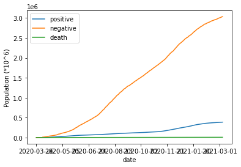

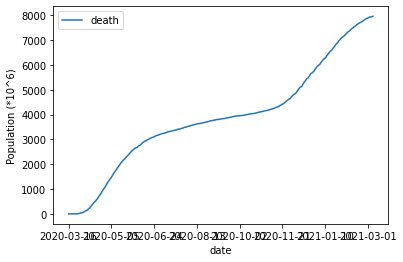

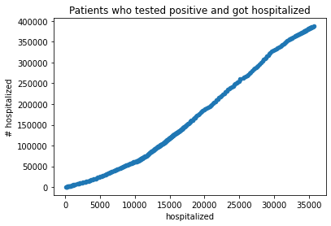

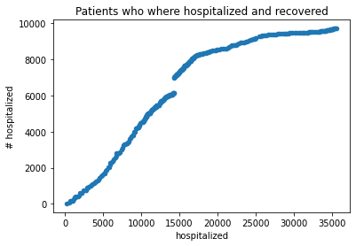

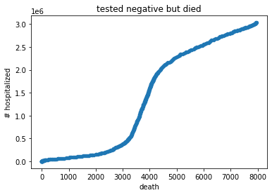

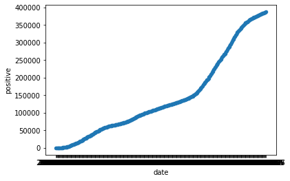

```python
#let ask some questions to the data and figure out if we can find more information
# data distribution accross time
data.plot(x='date', y=['positive', 'negative', 'death'], ylabel='Population (*10^6)')

data.plot(x='date', y='death', ylabel='Population (*10^6)')

# how does testing positive affect hospitalization?
data.plot.scatter(x='hospitalized', y='positive', title='Patients who tested positive and got hospitalized', ylabel='# hospitalized')#, 'negative', 'death', 'recovered'], ylabel='Population')

# among those who are hospitalized, what's the change of recovery?
data.plot.scatter(x='hospitalized', y='recovered', title='Patients who where hospitalized and recovered', ylabel='# hospitalized')#, 'negative', 'death', 'recovered'], ylabel='Population')

# death and testing negative
data.plot.scatter(x='death', y='negative', title='tested negative but died', ylabel='# hospitalized')#, 'negative', 'death', 'recovered'], ylabel='Population')

data.plot.scatter(x='date', y='positive')
```

```python
# first let's get the independent and dependen vairables
reg_data = data[['positive','death']].loc[data['death'].notna()]
ind = reg_data['positive']
dep = reg_data['death']

# # plit into training and test sets
ind_train, ind_test, dep_train, dep_test = train_test_split(ind, dep)

# ## fitting a linear model and training the model
lm = linear_model.LinearRegression()
lm.fit(ind_train.values.reshape(-1,1), dep_train)

# representing the linear regression
print(f"""Intercept: {lm.intercept_}\nCoef:{lm.coef_}
Equation: #Deaths = {lm.coef_} * #Positives + {lm.intercept_} """)
```

```
Intercept: 1578.409775398255
Coef:[0.01629503]
Equation: #Deaths = [0.01629503] * #Positives + 1578.409775398255
```

```python
ind_test.describe()
```

[output not shown]

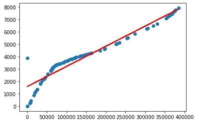

```python
# how'd we do?
predicted = lm.predict(ind_test.values.reshape(-1,1))
plt.plot(ind_test.values.reshape(-1,1), predicted, label='lm', color='r')
plt.scatter(ind_test.values.reshape(-1,1), dep_test, label='test data')
```